# Data Scientist Project

step 1: Define the research problem, objectives and muitivariate technique to be used: Dataset need to cleaned and to be used for predict continuous variable & category variable step 2: Develop the analysis plan step 3: Evalute the assuption underlying the statistical technique step 4: Estimate the statistical technique And access the overall model fit step 5: Interpret the variates step 6: validate the statistical model

HBAT Dataset its is hypothetical data from HBAT industry,

Dataset is about marketing research company which has different attributes whihc enables purchasing manager about data warehouse to increase the sales & customer statisfaction by examining below attributes:

Data warehouse classification variable: X1: Customer type: Non-Metric Length of the time a particular customer has been buying from HBAT: 1- Less than 1 Year 2- between 1 & 5 Year 3- 5 Year+

X2: Industry Type: Non-Metric Type of industry that purchase HBAT’s paper product: 0- Magazine Industry 1- Newspaper Industry

X4: Region: Non-Metric Customer location 0- USA/ North America 1- Outside USA/ North America

X5: distribution system: Non-Metric How paper product are sold to customer: 0-sold indirectly through a broker 1-sold directly

Performance perception variable:

X6: Product Quality: Metric Perceived value of quality of HBAT’s papaer product

X7:Ecommerce Activity/Website: Metric Overall image of HBAT’s website especially use friedliness

x8:Technical Support: Metric Extend to which technical support is offered to help solve product/service issues

x9:Complaint Resolution: Metric Extend to which any complaints are resolved in a timely and complete manners

x10:Adversitement: Metric Perception of HBAT’s advertising campaign in all type of media

x11: Product line :Metric Depth and breath of HBAT’s Product line to meet customer needs

x12:Salesforce Image: Metric Overall image of HBAT’s salesforce

x13:Competitive Pricing: Metric Extent to which HBAT offers competitive price

x14:Warranty & Claims: Metric Perception to which HBAT’s stand behind its product/service warrienties ans claims

x15:New Products: Metric Extent to which HBAT develop and sell new products

x16:Ordering & billing: Metric Perception that ordering and billing is handled effieciently ans correctly

x17:Price Flexibility: Metric Perceived willingness of HBAT sales reps to negotiate price on purchases of paper prodcuts

x18:Delivery Speed: Metric Amount of time it takes to deliver the paper products once on order has been confirmed

Outcome / Relationship Measure: x19:Satisfaction: Metric Customer statisfcation with past purchases from HBAT measured in a 10 point graphic rating scale

x20:Likehood of Recommendation: Metric Likelihood of recommendating HBAT to other frims as a suppier of paer product, measured on a 10 pint graphic rating scale

x22:Current Purchase / Usage Level: Metric Percentage fo the respounding firm’s paper needs purchases from HBAT’s measured on a 100 point percetage scale

x23:Consider stratigic Alliance / Partnership in future: Non-Metric Extent to whicch the customer/respondent perceives his or her firm would engage in strtegic alliance/paternership with HBAT

```r
library(class)
library(e1071)
library(caret)
library(klaR)
library(caTools)
library(PerformanceAnalytics)
library(car)
library(nortest)
library(Amelia)
library(Hmisc)
library(mlbench)
library(e1071)
library(caret)
library(DMwR)
library(PerformanceAnalytics)
library(VIM)
require(MASS)
library(rpart)
```

```r
library(VIM)
require(MASS)
library(ggplot2)
library(vioplot)
## Importing Dataset from SPSS file using foreign library
MT.HBAT  <-   foreign::read.spss (file = "E:/Multivariant ANalysis/Multivariate_Data_Analysis_7e_Datasets_and_Documentation/HBAT_200.sav",
                             to.data.frame = TRUE)
MT.HBAT  <-   as.data.frame (MT.HBAT)

attributes(MT.HBAT)$variable.labels
```

```
##                                  id                                  x1
##                                "ID"                "X1 - Customer Type"
##                                  x2                                  x3
##                "X2 - Industry Type"                    "X3 - Firm Size"
##                                  x4                                  x5
##                       "X4 - Region"          "X5 - Distribution System"
##                                  x6                                  x7
##              "X6 - Product Quality"                   "X7 - E-Commerce"
##                                  x8                                  x9
##            "X8 - Technical Support"         "X9 - Complaint Resolution"
##                                 x10                                 x11
##                 "X10 - Advertising"                "X11 - Product Line"
##                                 x12                                 x13
##            "X12 - Salesforce Image"         "X13 - Competitive Pricing"
##                                 x14                                 x15
##           "X14 - Warranty & Claims"                "X15 - New Products"
##                                 x16                                 x17
##             "X16 - Order & Billing"           "X17 - Price Flexibility"
##                                 x18                                 x19
##              "X18 - Delivery Speed"                "X19 - Satisfaction"
##                                 x20                                 x21
##         "X20 - Likely to Recommend"          "X21 - Likely to Purchase"
##                                 x22                                 x23
##              "X23 - Purchase Level" "X24 - Consider Strategic Alliance"
```

```r
names(MT.HBAT) <- c ("ID",
                  "X1.Customer_Type",
                  "X2.Industry_Type",
                  "X3.Firm_Size",
                  "X4.Region",
                  "X5.Distribution_System",
                  "X6.Product_Quality",
                  "X7.E.Commerce",
                  "X8.Technical_Support",
                  "X9.Complaint_Resolution",
                  "X10.Advertising",
                  "X11.Product_Line",
                  "X12.Salesforce_Image",
                  "X13.Competitive_Pricing",
                  "X14.Warranty_Claims",
                  "X15.New_Products",
                  "X16.Order_Billing",
                  "X17.Price_Flexibility",
                  "X18.Delivery_Speed",
                  "X19.Satisfaction",
                  "X20.Likely_to_Recommend",
                  "X21.Likely_to_Purchase",
                  "X22.Purchase_Level",
                  "X23.Consider_Strategic_Alliance")

attr (MT.HBAT, which="variable.labels", exact=TRUE)
```

```
##                                  id                                  x1
##                                "ID"                "X1 - Customer Type"
##                                  x2                                  x3
##                "X2 - Industry Type"                    "X3 - Firm Size"
##                                  x4                                  x5
##                       "X4 - Region"          "X5 - Distribution System"
##                                  x6                                  x7
##              "X6 - Product Quality"                   "X7 - E-Commerce"
##                                  x8                                  x9
##            "X8 - Technical Support"         "X9 - Complaint Resolution"
##                                 x10                                 x11
##                 "X10 - Advertising"                "X11 - Product Line"
##                                 x12                                 x13
##            "X12 - Salesforce Image"         "X13 - Competitive Pricing"
##                                 x14                                 x15
##           "X14 - Warranty & Claims"                "X15 - New Products"
##                                 x16                                 x17
##             "X16 - Order & Billing"           "X17 - Price Flexibility"
##                                 x18                                 x19
##              "X18 - Delivery Speed"                "X19 - Satisfaction"
##                                 x20                                 x21
##         "X20 - Likely to Recommend"          "X21 - Likely to Purchase"
##                                 x22                                 x23
##              "X23 - Purchase Level" "X24 - Consider Strategic Alliance"
```

```r
str (MT.HBAT)
```

```
## 'data.frame':    200 obs. of  24 variables:
##  $ ID                             : num  1 2 3 4 5 6 7 8 9 10 ...
##  $ X1.Customer_Type               : Factor w/ 3 levels "Less than 1 year",..: 2 3 3 1 2 1 1 2 2 1 ...
##  $ X2.Industry_Type               : Factor w/ 2 levels "Magazine industry",..: 1 2 1 2 1 2 2 1 2 1 ...
##  $ X3.Firm_Size                   : Factor w/ 2 levels "Small (0 to 499)",..: 2 1 2 2 2 1 2 2 2 2 ...
##  $ X4.Region                      : Factor w/ 2 levels "USA/North America",..: 2 1 2 2 1 2 2 2 2 2 ...
##  $ X5.Distribution_System         : Factor w/ 2 levels "Indirect through broker",..: 2 1 2 1 2 1 1 1 1 1 ...
##  $ X6.Product_Quality             : atomic  8.5 8.2 9.2 6.4 9 6.5 6.9 6.2 5.8 6.4 ...
##   ..- attr(*, "value.labels")= Named num  10 0
##   .. ..- attr(*, "names")= chr  "Excellent" "Poor"
##  $ X7.E.Commerce                  : atomic  3.9 2.7 3.4 3.3 3.4 2.8 3.7 3.3 3.6 4.5 ...
##   ..- attr(*, "value.labels")= Named num  10 0
##   .. ..- attr(*, "names")= chr  "Excellent" "Poor"
##  $ X8.Technical_Support           : atomic  2.5 5.1 5.6 7 5.2 3.1 5 3.9 5.1 5.1 ...
##   ..- attr(*, "value.labels")= Named num  10 0
##   .. ..- attr(*, "names")= chr  "Excellent" "Poor"
##  $ X9.Complaint_Resolution        : atomic  5.9 7.2 5.6 3.7 4.6 4.1 2.6 4.8 6.7 6.1 ...
##   ..- attr(*, "value.labels")= Named num  10 0
##   .. ..- attr(*, "names")= chr  "Excellent" "Poor"
##  $ X10.Advertising                : atomic  4.8 3.4 5.4 4.7 2.2 4 2.1 4.6 3.7 4.7 ...
##   ..- attr(*, "value.labels")= Named num  10 0
##   .. ..- attr(*, "names")= chr  "Excellent" "Poor"
##  $ X11.Product_Line               : atomic  4.9 7.9 7.4 4.7 6 4.3 2.3 3.6 5.9 5.7 ...
##   ..- attr(*, "value.labels")= Named num  10 0
##   .. ..- attr(*, "names")= chr  "Excellent" "Poor"
##  $ X12.Salesforce_Image           : atomic  6 3.1 5.8 4.5 4.5 3.7 5.4 5.1 5.8 5.7 ...
##   ..- attr(*, "value.labels")= Named num  10 0
##   .. ..- attr(*, "names")= chr  "Excellent" "Poor"
##  $ X13.Competitive_Pricing        : atomic  6.8 5.3 4.5 8.8 6.8 8.5 8.9 6.9 9.3 8.4 ...
##   ..- attr(*, "value.labels")= Named num  10 0
##   .. ..- attr(*, "names")= chr  "Excellent" "Poor"
##  $ X14.Warranty_Claims            : atomic  4.7 5.5 6.2 7 6.1 5.1 4.8 5.4 5.9 5.4 ...
##   ..- attr(*, "value.labels")= Named num  10 0
##   .. ..- attr(*, "names")= chr  "Excellent" "Poor"
##  $ X15.New_Products               : atomic  4.3 4 4.6 3.6 4.5 9.5 2.5 4.8 4.4 5.3 ...
##   ..- attr(*, "value.labels")= Named num  10 0
##   .. ..- attr(*, "names")= chr  "Excellent" "Poor"
##  $ X16.Order_Billing              : atomic  5 3.9 5.4 4.3 4.5 3.6 2.1 4.3 4.4 4.1 ...
##   ..- attr(*, "value.labels")= Named num  10 0
##   .. ..- attr(*, "names")= chr  "Excellent" "Poor"
##  $ X17.Price_Flexibility          : atomic  5.1 4.3 4 4.1 3.5 4.7 4.2 6.3 6.1 5.8 ...
##   ..- attr(*, "value.labels")= Named num  10 0
##   .. ..- attr(*, "names")= chr  "Excellent" "Poor"
##  $ X18.Delivery_Speed             : atomic  3.7 4.9 4.5 3 3.5 3.3 2 3.7 4.6 4.4 ...
##   ..- attr(*, "value.labels")= Named num  10 0
##   .. ..- attr(*, "names")= chr  "Excellent" "Poor"
##  $ X19.Satisfaction               : atomic  8.2 5.7 8.9 4.8 7.1 4.7 5.7 6.3 7 5.5 ...
##   ..- attr(*, "value.labels")= Named num  100 0
##   .. ..- attr(*, "names")= chr  "Completely Satisfied" "Not At All Satisfied"
##  $ X20.Likely_to_Recommend        : atomic  8 6.5 8.4 6 6.6 6.3 7.8 5.8 7.5 5.9 ...
##   ..- attr(*, "value.labels")= Named num  10 0
##   .. ..- attr(*, "names")= chr  "Definitely" "Not At All"
##  $ X21.Likely_to_Purchase         : atomic  8.4 7.5 9 7.2 9 6.1 7.2 7.7 8.2 6.7 ...
##   ..- attr(*, "value.labels")= Named num  10 0
##   .. ..- attr(*, "names")= chr  "Definitely" "Not At All"
##  $ X22.Purchase_Level             : atomic  65.1 67.1 72.1 40.1 57.1 50.1 41.1 56.1 56.1 59.1 ...
##   ..- attr(*, "value.labels")= Named num  100 0
##   .. ..- attr(*, "names")= chr  "100 Percent" "Zero Percent"
##  $ X23.Consider_Strategic_Alliance: Factor w/ 2 levels "No, would not consider",..: 2 1 2 1 1 1 1 1 2 1 ...
##  - attr(*, "variable.labels")= Named chr  "ID" "X1 - Customer Type" "X2 - Industry Type" "X3 - Firm Size" ...
##   ..- attr(*, "names")= chr  "id" "x1" "x2" "x3" ...
```

```r
names (MT.HBAT)
```

```
##  [1] "ID"                              "X1.Customer_Type"
##  [3] "X2.Industry_Type"                "X3.Firm_Size"
##  [5] "X4.Region"                       "X5.Distribution_System"
##  [7] "X6.Product_Quality"              "X7.E.Commerce"
##  [9] "X8.Technical_Support"            "X9.Complaint_Resolution"
## [11] "X10.Advertising"                 "X11.Product_Line"
## [13] "X12.Salesforce_Image"            "X13.Competitive_Pricing"
## [15] "X14.Warranty_Claims"             "X15.New_Products"
## [17] "X16.Order_Billing"               "X17.Price_Flexibility"
## [19] "X18.Delivery_Speed"              "X19.Satisfaction"
## [21] "X20.Likely_to_Recommend"         "X21.Likely_to_Purchase"
## [23] "X22.Purchase_Level"              "X23.Consider_Strategic_Alliance"
```

```r
dim (MT.HBAT)
```

```
## [1] 200  24
```

```r
sum (is.na(MT.HBAT))
```

```
## [1] 0
```

```r
MT.HBAT<-na.omit (MT.HBAT)
```

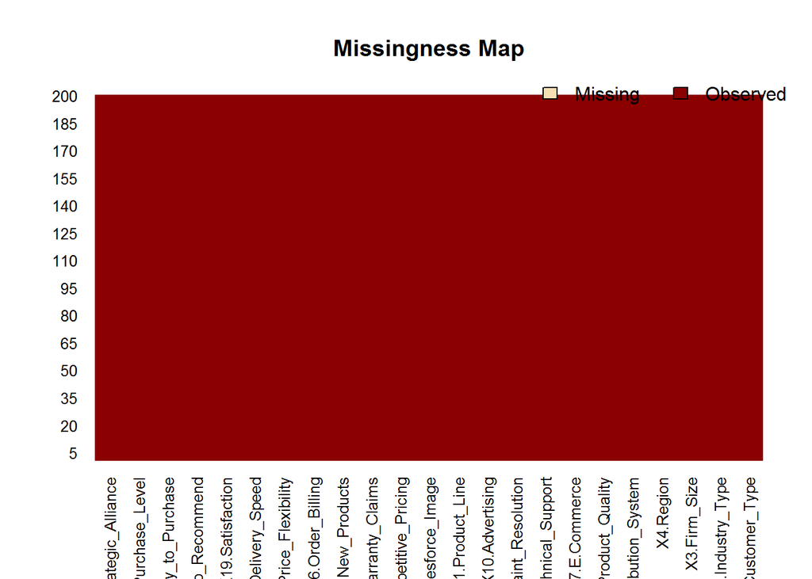

```r
##??missmap
windows.options (reset=TRUE)
windows.options(width=8, height=8)

## Graphical representation for MIssing value in HBAT Data set
missmap (MT.HBAT[,-1])
```

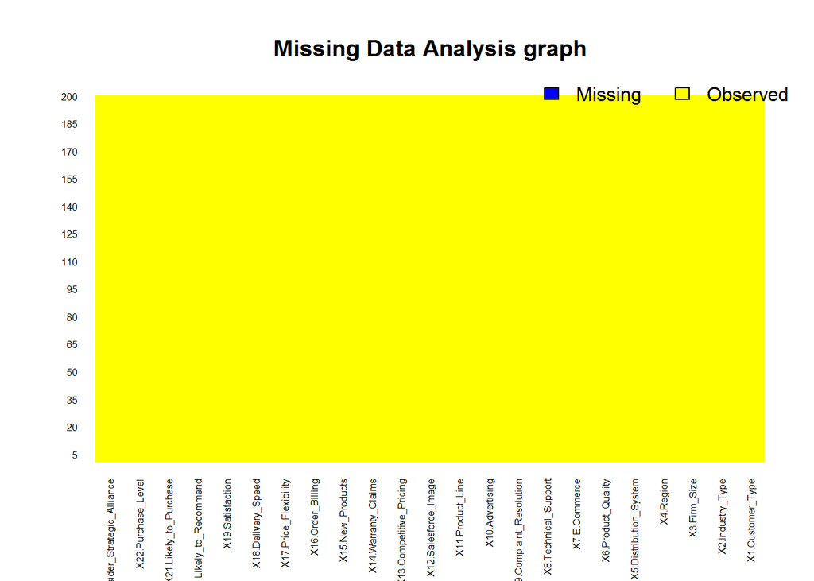

```r
## MIssing value of HBAT Data set with some color attributes
missmap (MT.HBAT[,-1],
         main="Missing Data Analysis graph",
         ##xlab=names(MT.HBAT[,-1]),
         cex.axis=10.5,
         ##ylab="Proportion of MissingData",
         legend = TRUE,
         col = c("blue", "yellow"),
         legend.pos="topleft",
         y.cex = 0.5, x.cex = 0.5, hang=1,xaxt = "n")
```

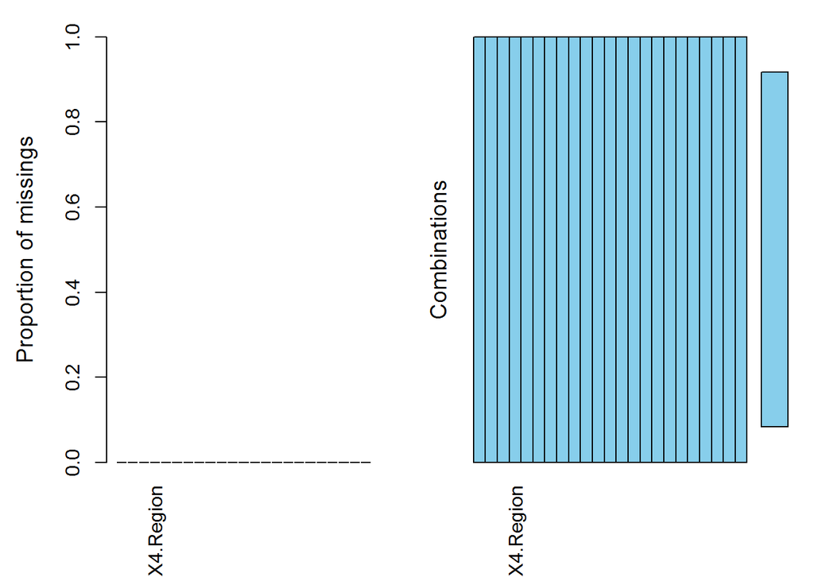

```r
#OR
aggr (MT.HBAT[,-1],axes = TRUE)
```

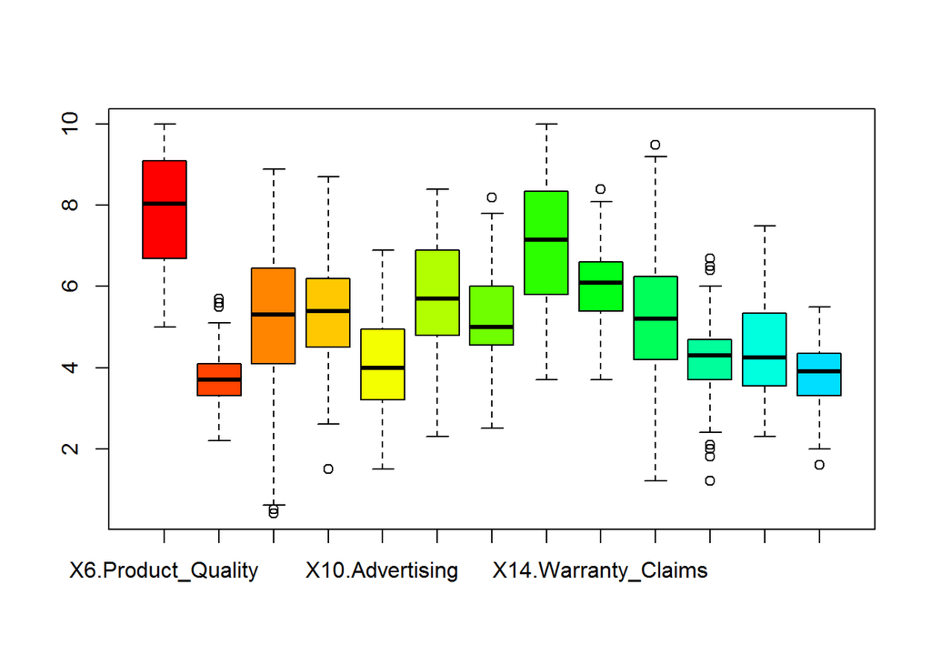

```r
##Graphs & Plots
MT.HBAT2  <-  MT.HBAT[,-1]

boxplot(MT.HBAT2[,6:18],varwidth=T,col=rainbow(length(MT.HBAT2)))
```

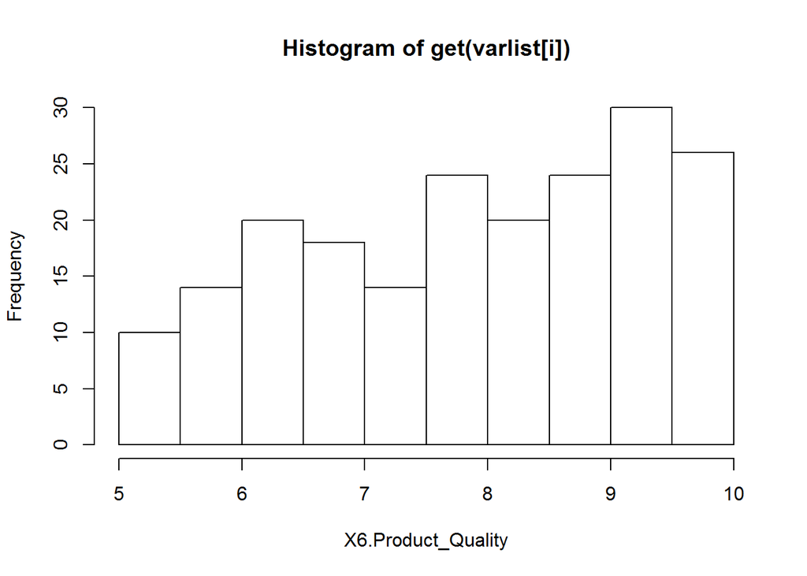

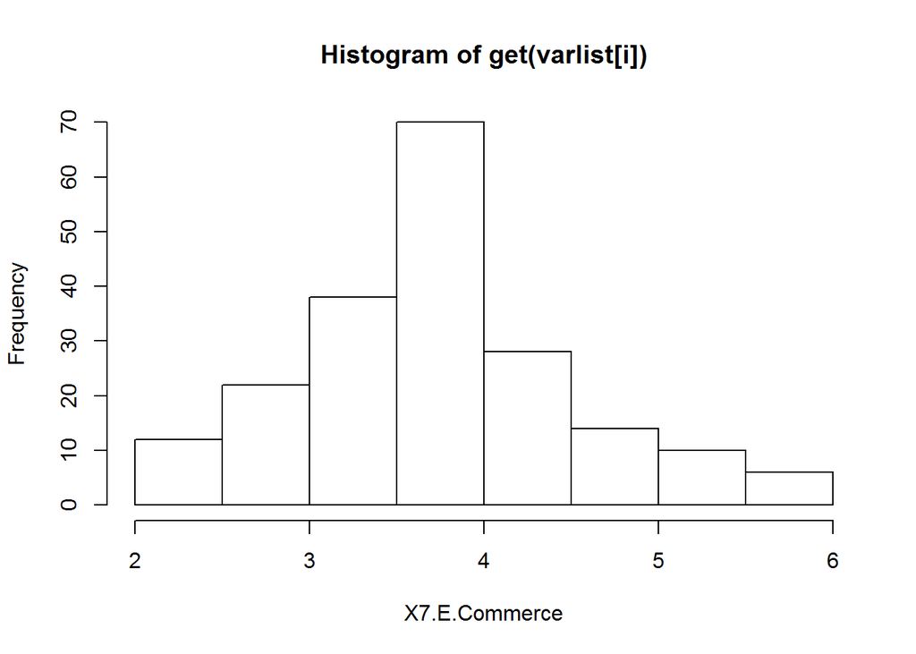

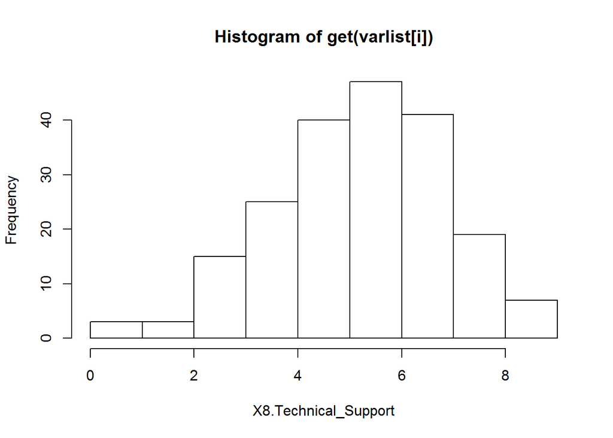

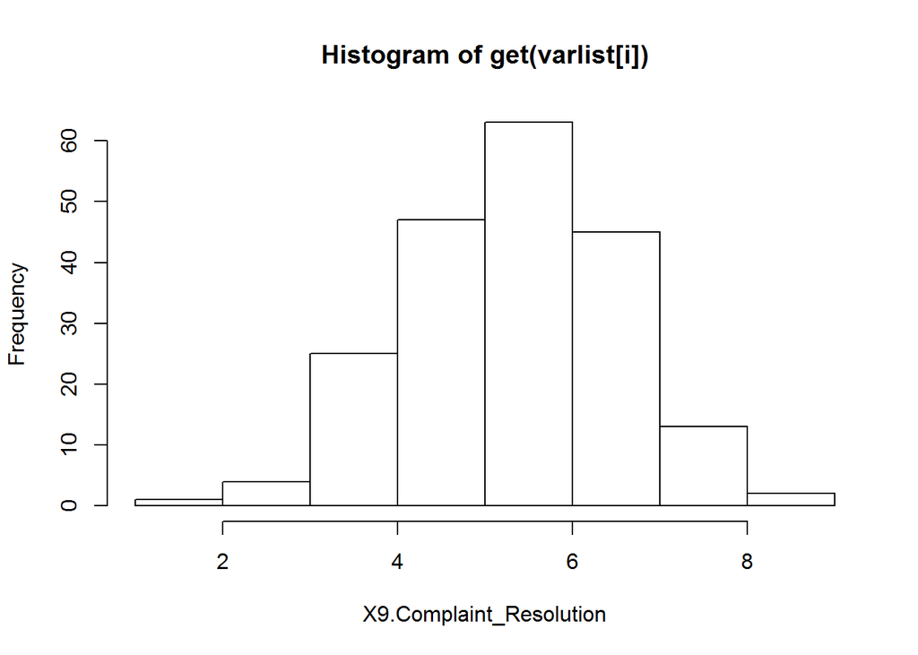

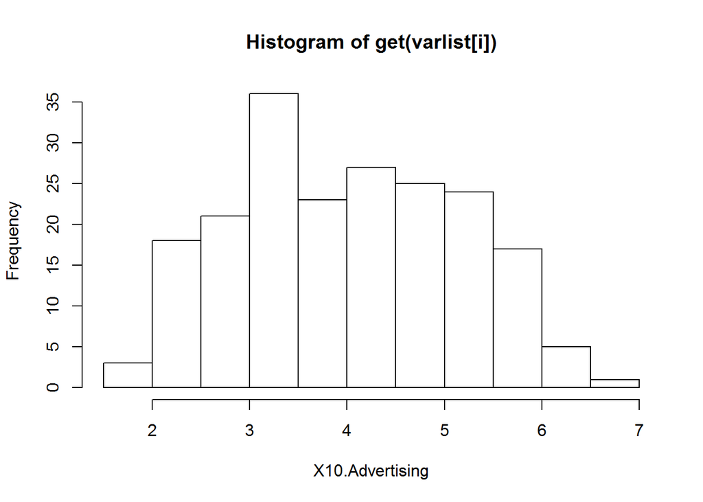

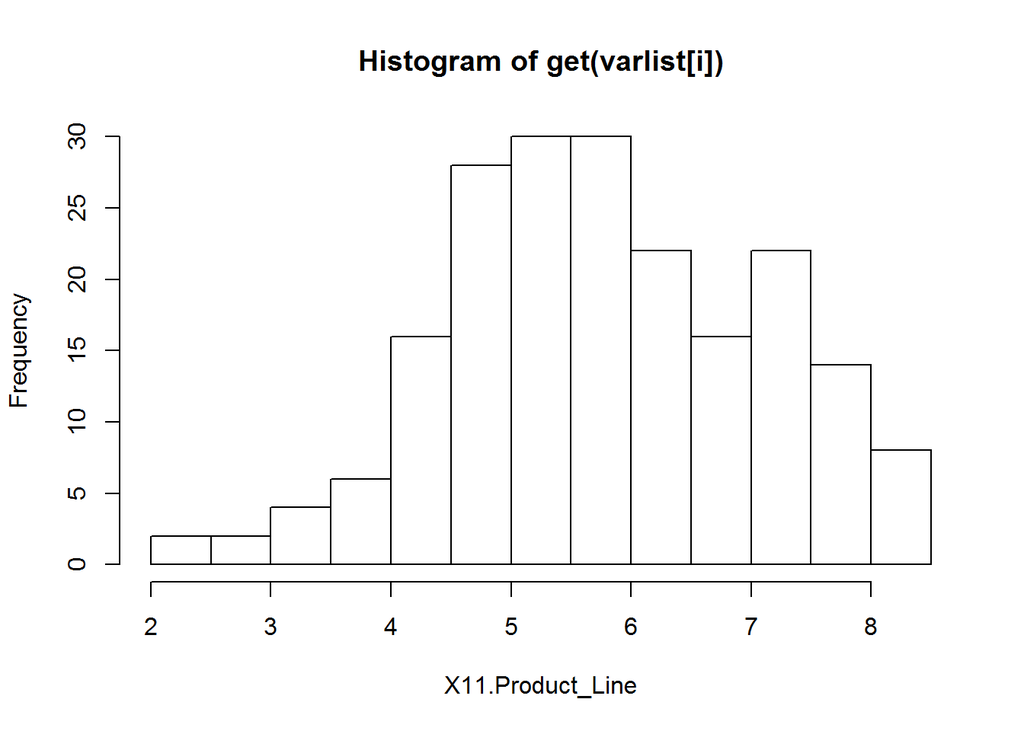

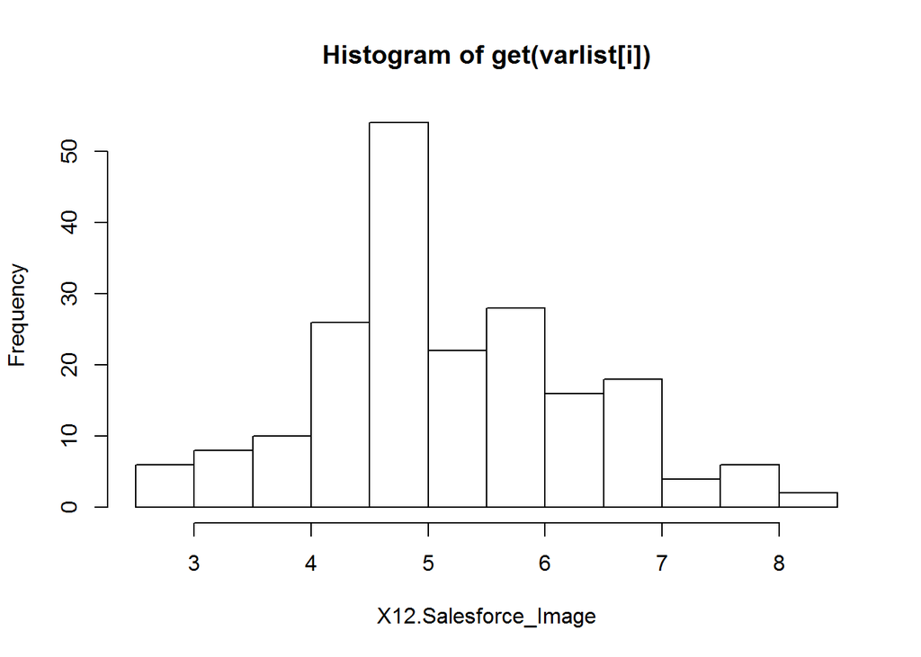

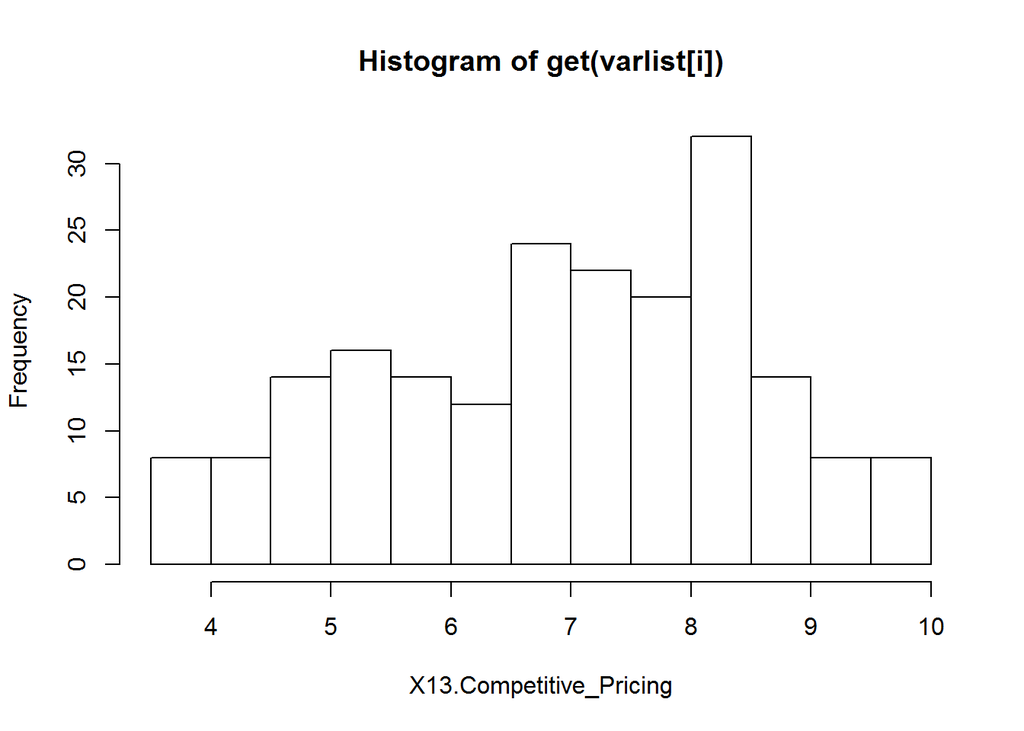

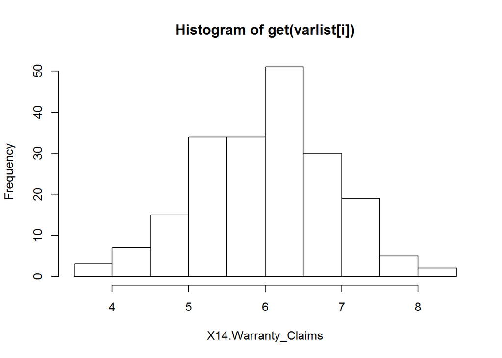

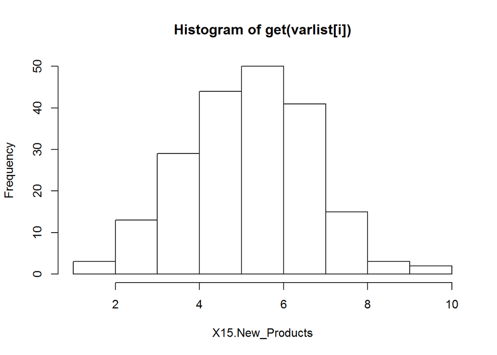

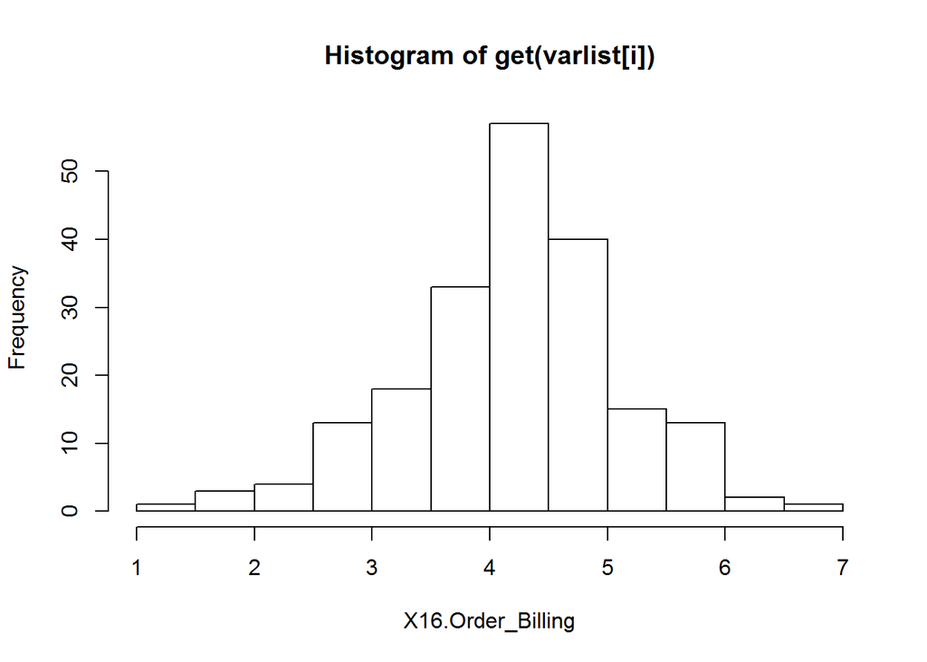

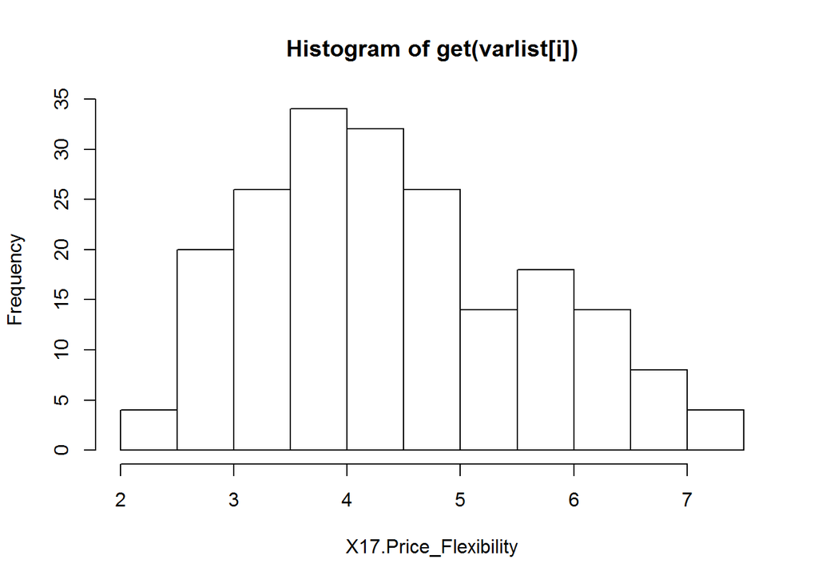

[5 more figures not shown]

```r
## Extracting the Continuos variable under descriptive study from the data set
varlist  <-  names(MT.HBAT2[,6:22])
attach(MT.HBAT2)
for (i in 1:length(varlist))
{
    hist(get(varlist[i]),xlab=varlist[i] )
}
```

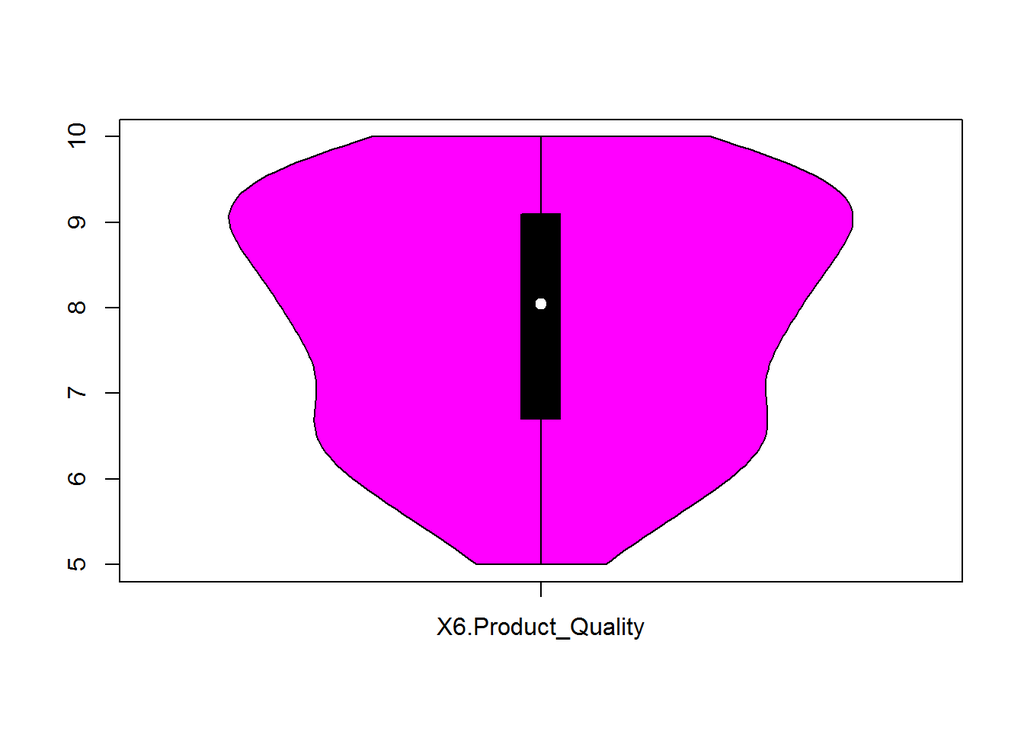

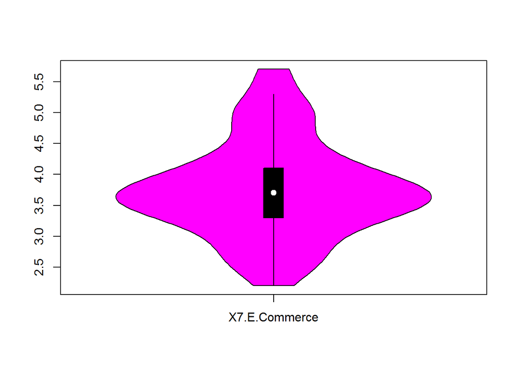

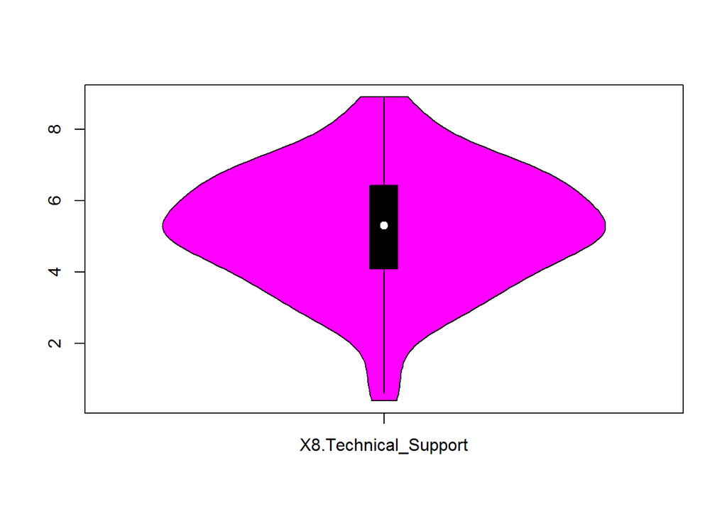

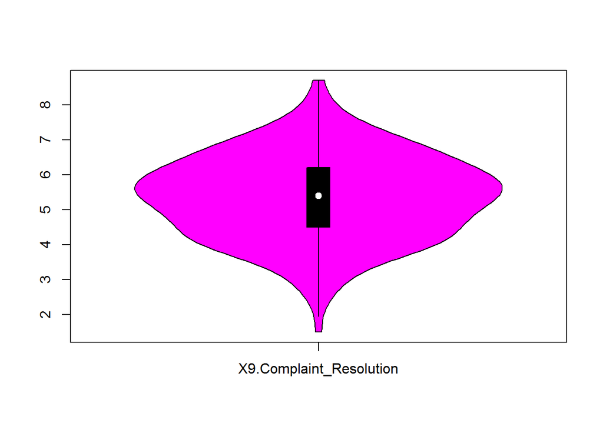

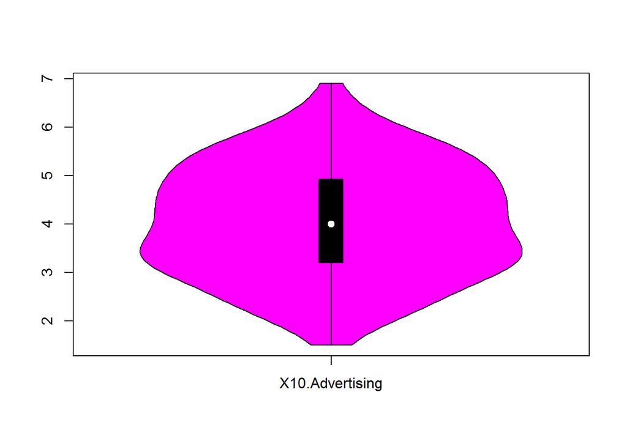

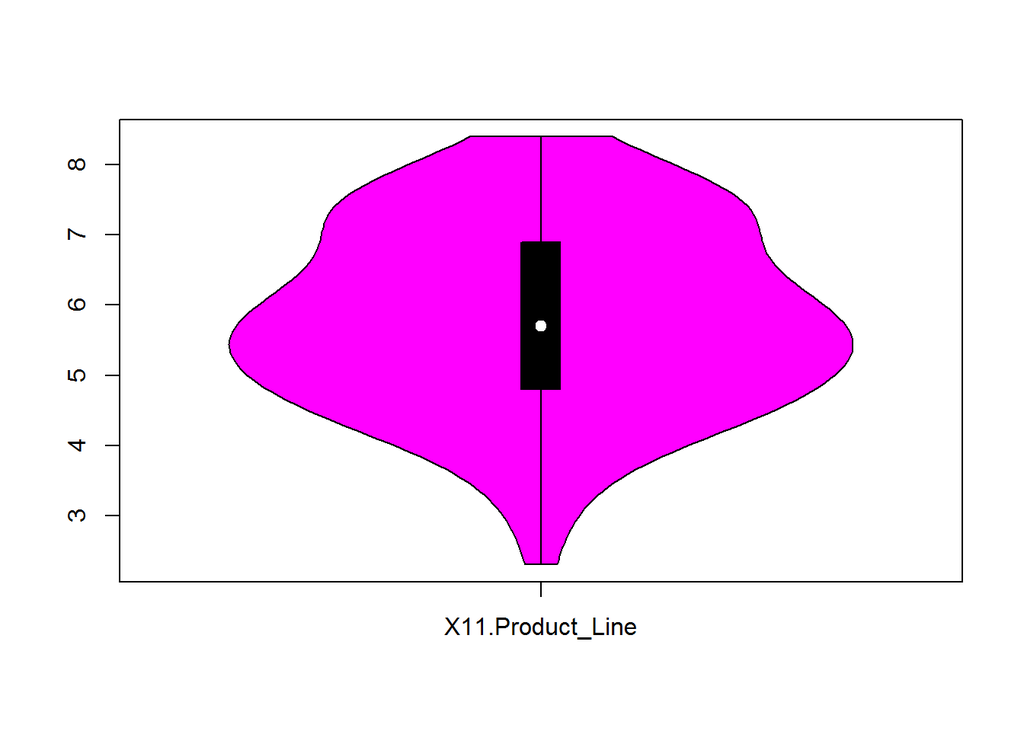

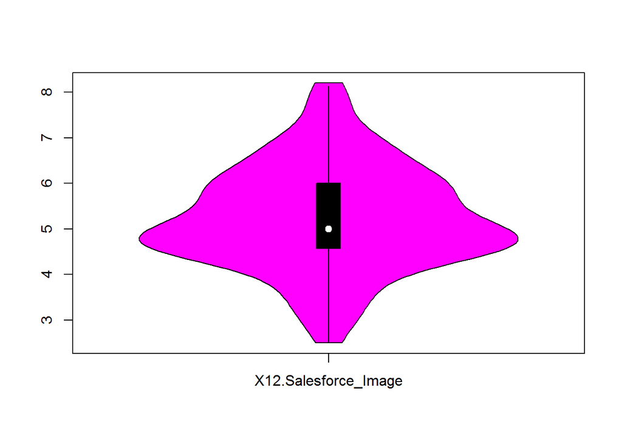

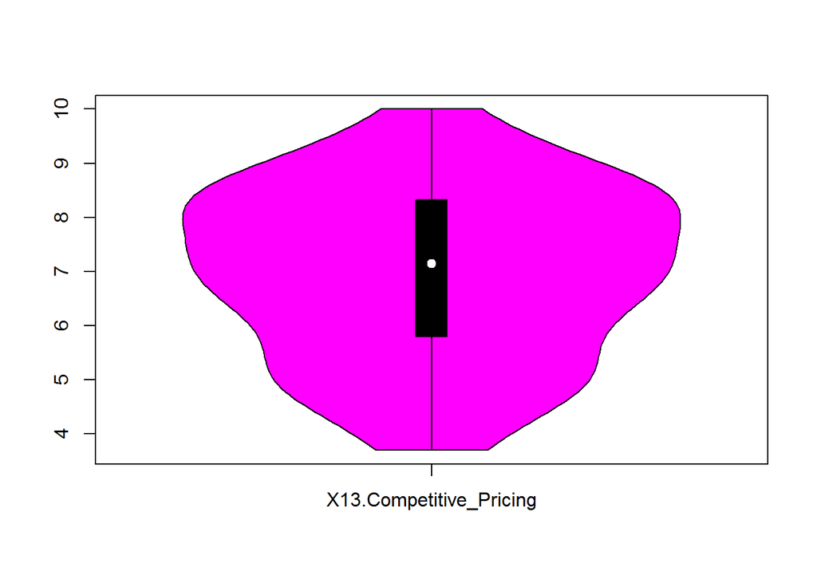

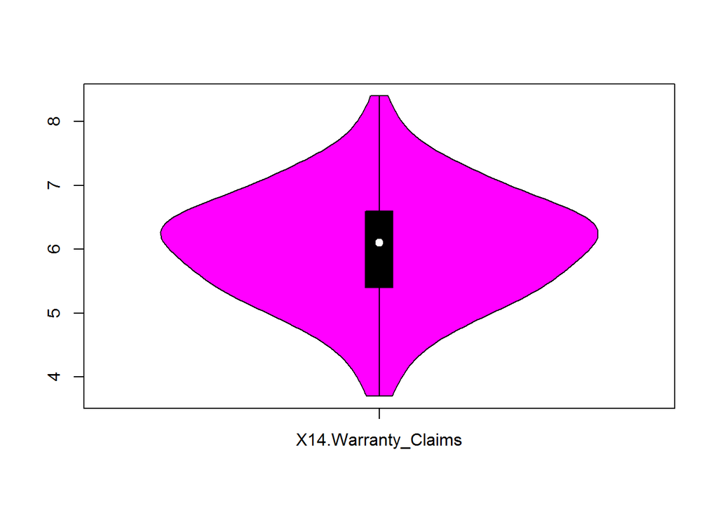

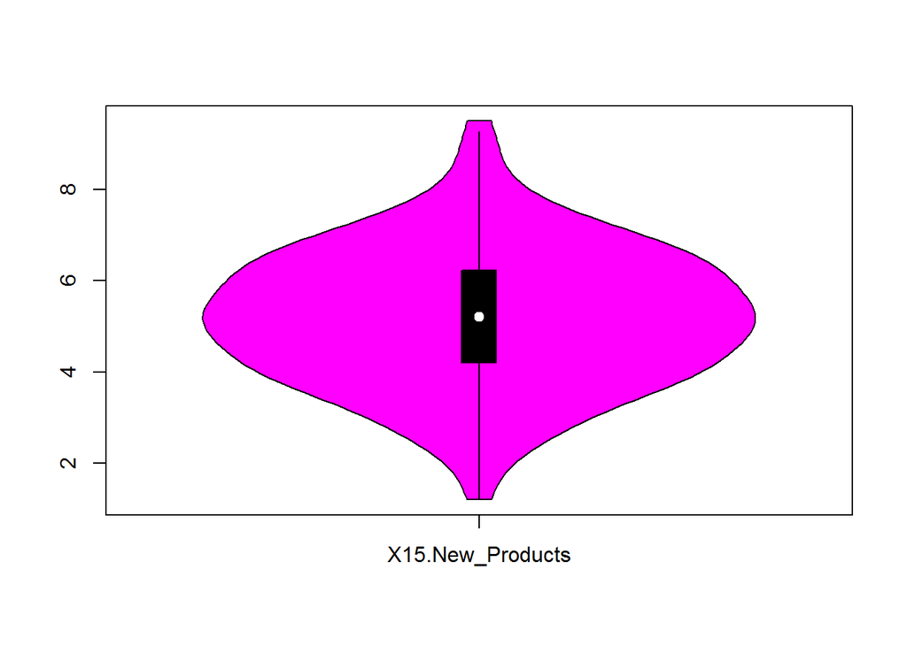

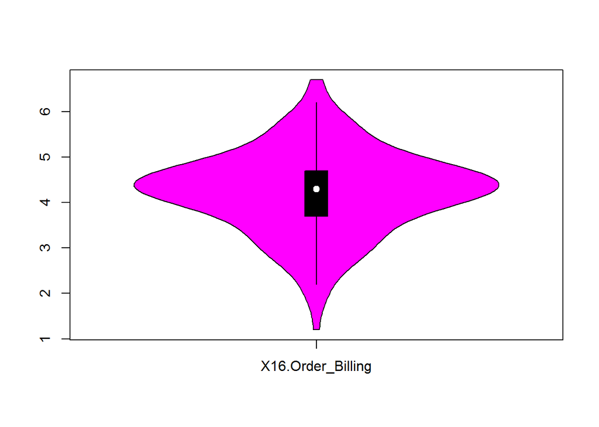

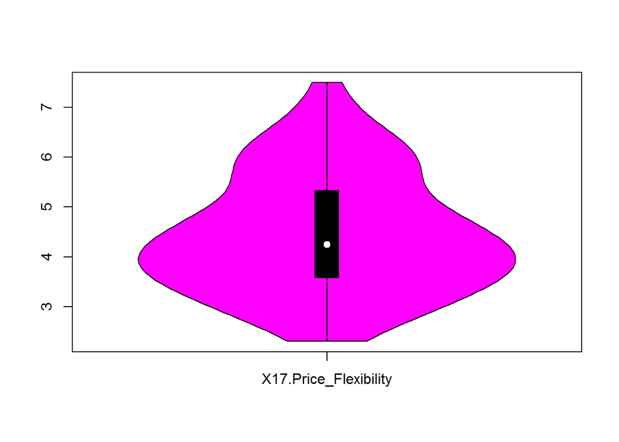

[5 more figures not shown]

```r
for (i in 1:length(varlist))
{
    vioplot(get(varlist[i]),names=varlist[i])
}
```

```r
# DISTANCE BASED APPROACH FOR OUTLIER DETECTION
library(DMwR)
MT.HBAT2  <-  MT.HBAT[,-1]
outlier.scores   <-  lofactor(MT.HBAT2[,6:22],k = 5)
outliers   <-   order(outlier.scores, decreasing=T)[1:5]
outliers
```

```
## [1] 104 195 149 130   7
```

```r
print(outliers)
```

```
## [1] 104 195 149 130   7
```

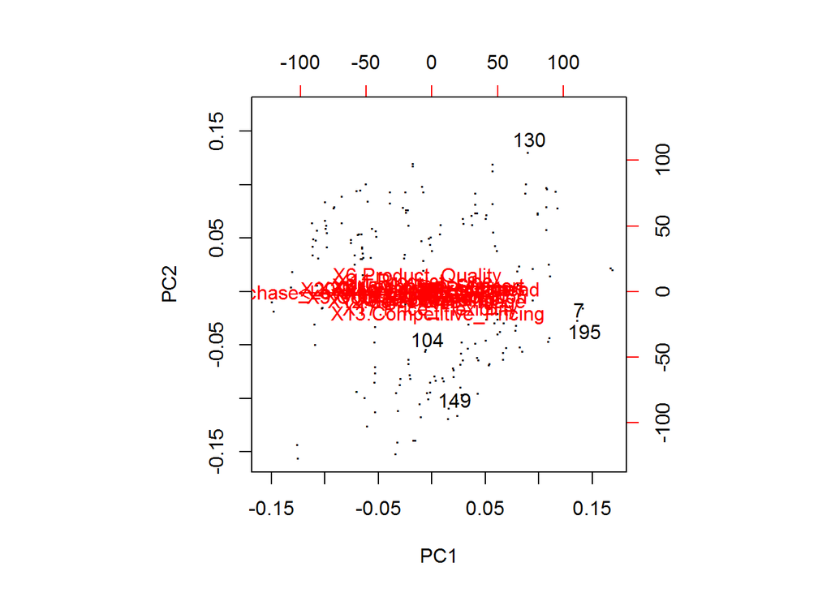

```r
n   <-   nrow(MT.HBAT2)

labels   <-   1:n
labels[-outliers]   <-   "."
biplot(prcomp(MT.HBAT2[,6:22]), cex=1, xlabs=labels)
```

```r
## Remove Outliers from the dataset
MT.HBAT2  <-   MT.HBAT2[-outliers,]

dim(MT.HBAT2)
```

```
## [1] 195  23
```

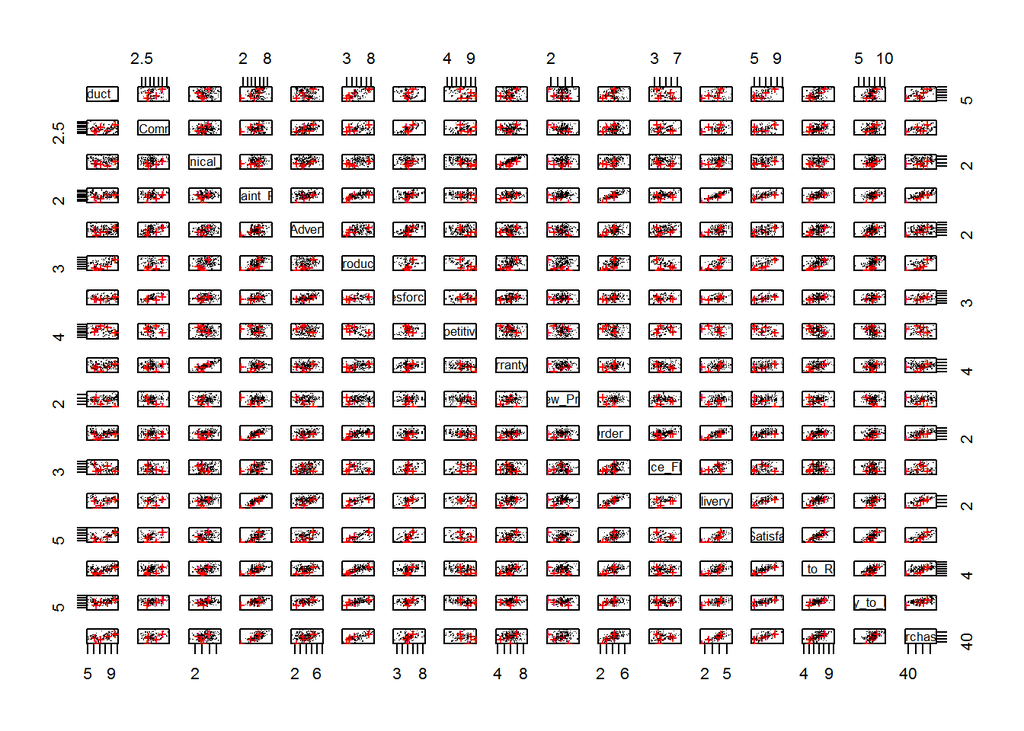

```r
pch   <-   rep(".", n)
pch[outliers]   <-   "+"
col   <-   rep("black", n)
col[outliers]   <-   "red"
pairs(MT.HBAT2[,6:22], pch=pch, col=col)
```

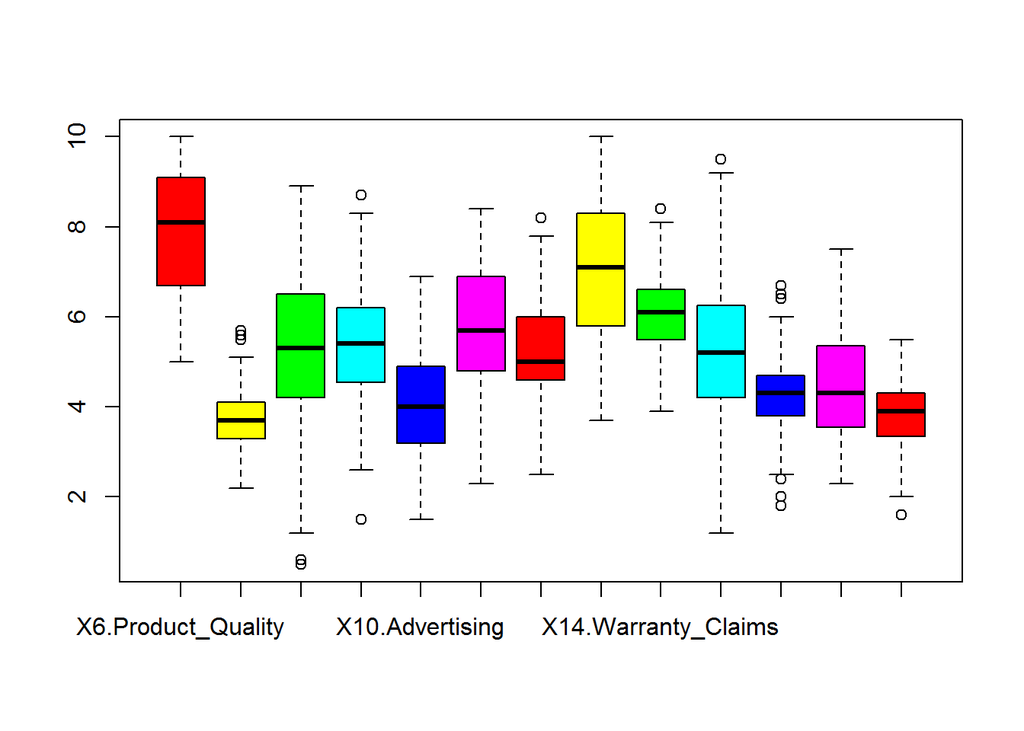

```r
boxplot(MT.HBAT2[,6:18],col=rainbow(6:18))
```

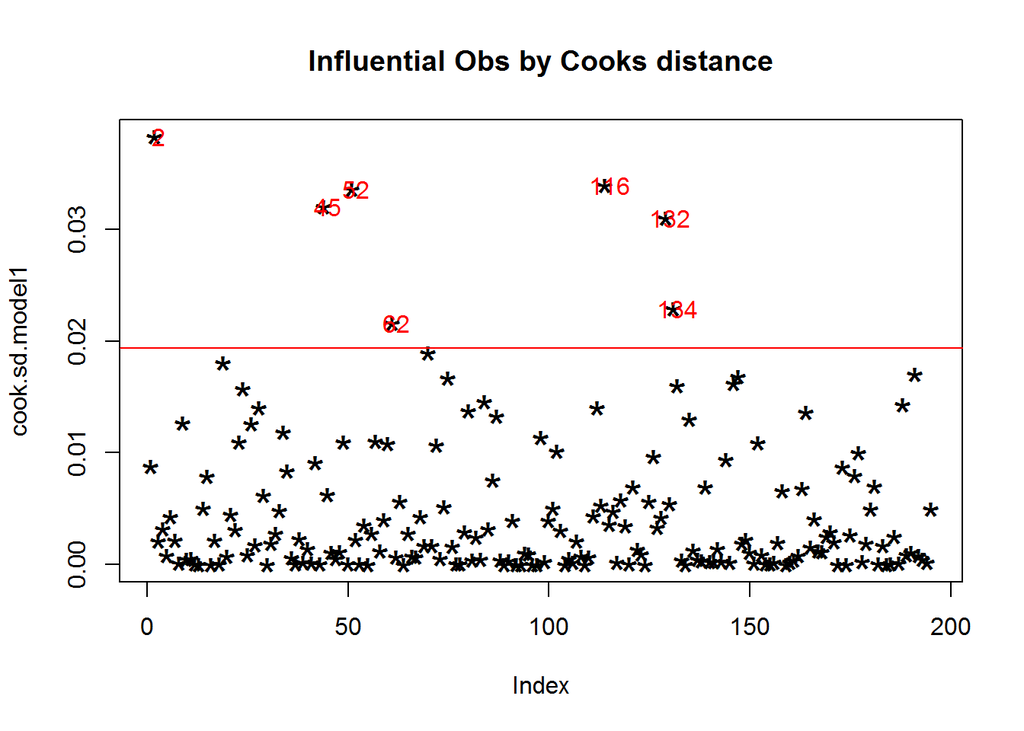

```r
# DISTANCE BASED APPROACH FOR OUTLIER DETECTION

model1  <-   lm(X19.Satisfaction
~X6.Product_Quality+X7.E.Commerce+X8.Technical_Support+X9.Complaint_Resolution+X10.Advertising+X11.Product_Line+X12.Salesforce_Image+X13.Competitive_Pricing+X14.Warranty_Claims+X15.New_Products+X16.Order_Billing+X17.Price_Flexibility+X18.Delivery_Speed,MT.HBAT2)
cook.sd.model1  <-   cooks.distance(model1)
plot(cook.sd.model1, pch="*", cex=2, main="Influential Obs by Cooks distance")  # plot

##Threshold Need to defined
abline(h = 4*mean(cook.sd.model1, na.rm=T), col="red")  # add cutoff line
text(x=1:length(cook.sd.model1)+1, y=cook.sd.model1, labels=ifelse(cook.sd.model1>4*mean(cook.sd.model1, na.rm=T),names(cook.sd.model1),""), col="red")  # add labels
```